# Stack Layout

`stack_layout()` put plots horizontally or vertically. You can also use the alias `ggstack()`.

```r
library(ggalign)
```

## Input data

The data input can be a numeric or character vector, a matrix, and a data frame. Simple vector will be converted into a one column matrix.

```r
set.seed(123)
small_mat <- matrix(rnorm(81), nrow = 9)
rownames(small_mat) <- paste0("row", seq_len(nrow(small_mat)))
colnames(small_mat) <- paste0("column", seq_len(ncol(small_mat)))
```

By default, `ggstack()` will create the layout, but no plot will be drawn until you add a plot element:

```r
ggstack(small_mat)
```

We can add any `align_*()` function to customize the layout or integrate plots into the stack.

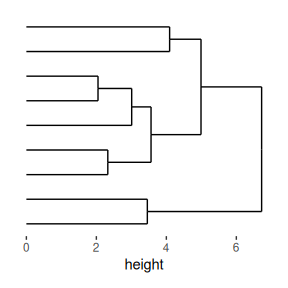

```r
ggstack(small_mat) + align_dendro()
```

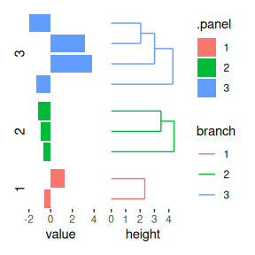

```r
ggstack(small_mat) +
    align_kmeans(centers = 3L) +
    ggalign(data = rowSums) +
    geom_bar(aes(value, fill = .panel), orientation = "y", stat = "identity") +
    facet_grid(switch = "y") +
    theme(strip.text = element_text()) +
    align_dendro(aes(color = branch))
```

By default, `ggstack()` arranges the plots horizontally. To change the direction to vertical, use the `direction` argument:

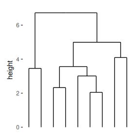

```r
ggstack(small_mat, "v") + align_dendro()
```

> Note that vertical stack take the `x-axis` as the observations, but horizontal stack take the `y-axis` as the observations.

## Data frame Input

Unlike `heatmap_layout()`/`ggheatmap()`, data frames are not automatically converted into a matrix within `ggstack()`.

When using data frames, be cautious as many `align_*()` functions only accept matrix. If the necessary data is not explicitly provided to an `align_*()` function, the data frame from `ggstack()` will be passed to the function and internally converted into a matrix, which may result in missing values.

An exception is the `align_gg()`/`ggalign()` function, which can handle both matrix and data frames. When the input is a matrix (or a simple vector), it will be transformed into a long-format data frame. When the input is a data frame, only the necessary panel and axis information will be added to the data frame.

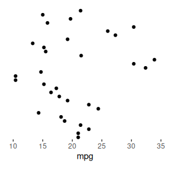

```r
ggstack(mtcars) +
    ggalign(aes(mpg)) +
    geom_point()
```

Note `align_gg()`/`ggalign()` always applies a default mapping for the parallel axes of the data index within the layout. This mapping is `aes(y = .data$.y)` for horizontal stack and `aes(x = .data$.x)` for vertical stack. So here we only provide mapping for the `x-axis`.

For more information on adding plots, refer to the vignette: `vignette("layout-plot")`.

## Heatmap plot

Besides the `align_*()` functions, we can also add the `heatmap_layout()`/`ggheatmap()` into the stack layout.

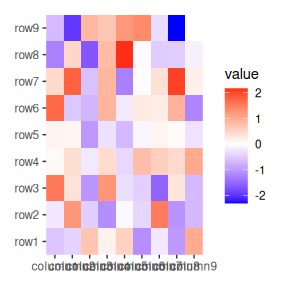

```r
ggstack(small_mat) +
    ggheatmap()
```

As mentioned earlier, vertical stacks use the `x-axis` for observations, while horizontal stacks use the `y-axis`. However, heatmap layouts always use the y-axis for observations. When a heatmap layout is added to a vertical stack layout, the inherited data is automatically converted to a matrix and transposed before use.

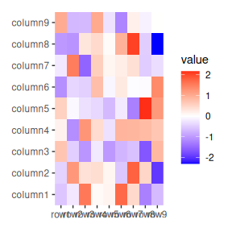

```r
ggstack(small_mat, direction = "v") +
    ggheatmap()
```

Once a heatmap layout is added, any further elements you add will be applied to this heatmap layout. You can include `align_*` elements or any ggplot2 components for the heatmap.

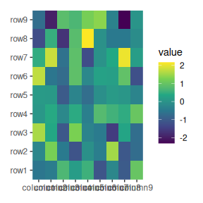

```r
ggstack(small_mat) +
    ggheatmap() +
    scale_fill_viridis_c()
```

If you’d like to add elements to the stack layout rather than the heatmap layout, you can easily switch from the heatmap layout to the stack layout using `stack_active()`.

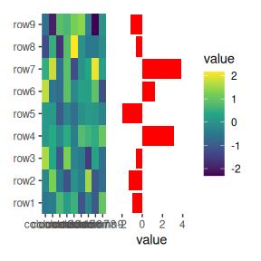

```r
ggstack(small_mat) +
    ggheatmap() +
    scale_fill_viridis_c() +
    stack_active() +
    ggalign(data = rowSums) +
    geom_bar(aes(value), fill = "red", orientation = "y", stat = "identity")
```

One exception is the heatmap layout itself, which cannot be added to another heatmap layout. Therefore, you can directly add a heatmap layout to the stack layout without using `stack_active()`.

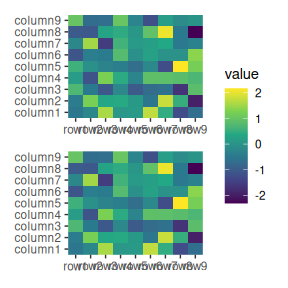

```r
ggstack(small_mat, "v") +
    ggheatmap() +
    ggheatmap() &
    scale_fill_viridis_c()
```

## Control sizes

A length of 3 sizes should be provided in `ggstack()` when putting a heatmap with flank annotation into the stack layout. For vertical stacks, this means heatmaps with left or right annotations; for horizontal stacks, this means heatmaps with top or bottom annotations. The first size controls the relative width/height of the left or top annotation, the second controls the relative size of the heatmap body width/height, and the third controls the relative width/height of the right or bottom annotation.

By default the three rows/columns will have equal sizes.

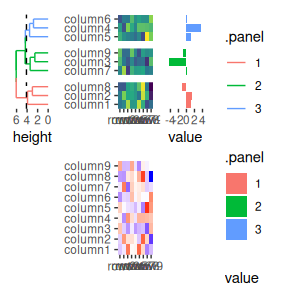

```r
ggstack(small_mat, "v") +
    ggheatmap() +
    scale_fill_viridis_c() +
    hmanno("l") +
    align_dendro(aes(color = .panel), k = 3L) +
    hmanno("r") +
    ggalign(data = rowSums) +
    geom_bar(aes(value, fill = .panel), orientation = "y", stat = "identity") +
    ggheatmap()
```

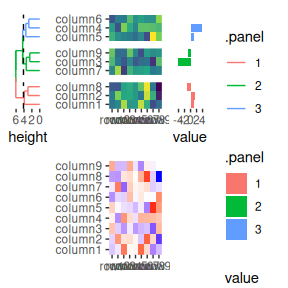

```r
ggstack(small_mat, "v", c(1, 2, 1)) +
    ggheatmap() +
    scale_fill_viridis_c() +
    hmanno("l") +
    align_dendro(aes(color = .panel), k = 3L) +
    hmanno("r") +
    ggalign(data = rowSums) +
    geom_bar(aes(value, fill = .panel), orientation = "y", stat = "identity") +
    ggheatmap()
```

In this way, heatmap body width/height specified in `hmanno()` or `ggheatmap()` won’t work.

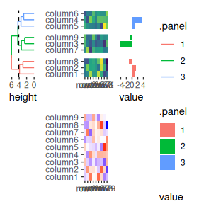

```r
ggstack(small_mat, "v") +
    ggheatmap() +
    scale_fill_viridis_c() +
    hmanno("l") +
    align_dendro(aes(color = .panel), k = 3L) +
    hmanno("r") +
    ggalign(data = rowSums) +
    geom_bar(aes(value, fill = .panel), orientation = "y", stat = "identity") +
    ggheatmap(.width = unit(2, "null"))
```

By default the flank annotation will fill the whole stack flank, but we can still control the total size of heatmap annotation in `hmanno()`.

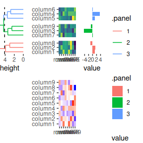

```r
ggstack(small_mat, "v") +
    ggheatmap() +
    scale_fill_viridis_c() +
    hmanno("l", size = unit(2, "cm")) +
    align_dendro(aes(color = .panel), k = 3L) +
    hmanno("r") +
    ggalign(data = rowSums) +
    geom_bar(aes(value, fill = .panel), orientation = "y", stat = "identity") +
    ggheatmap()
```

You can also use `npc` unit.

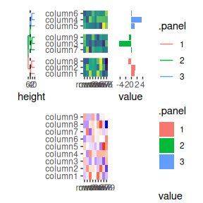

```r
ggstack(small_mat, "v") +
    ggheatmap() +
    scale_fill_viridis_c() +
    hmanno("l", size = unit(0.5, "npc")) +
    align_dendro(aes(color = .panel), k = 3L) +
    hmanno("r") +
    ggalign(data = rowSums) +
    geom_bar(aes(value, fill = .panel), orientation = "y", stat = "identity") +
    ggheatmap()
```